# Seed Pod Wind Dispersal of Holmgren’s Milk-vetch, Astragalus holmgreniorum

Sydney Houghton

4/26/2018

### Introduction

Astragalus holmgreniorum is an endangered endemic perennial herb of the Northern Mojave Desert near St. George, UT. The morphological characteristics of the leguminous pods at the stage they begin to loose seeds exhibits aerodynamic qualities. This study was performed to determine if wind dispersal is possible and what distance will pods potentially move.

### Data Analysis

Of the 324 trials 89% of pods moved a distance and stopped within 15 seconds of wind exposure and 57% travled to 152.4 cm or more. Runway maximum length is 304.8 cm, roughly 3 meters.

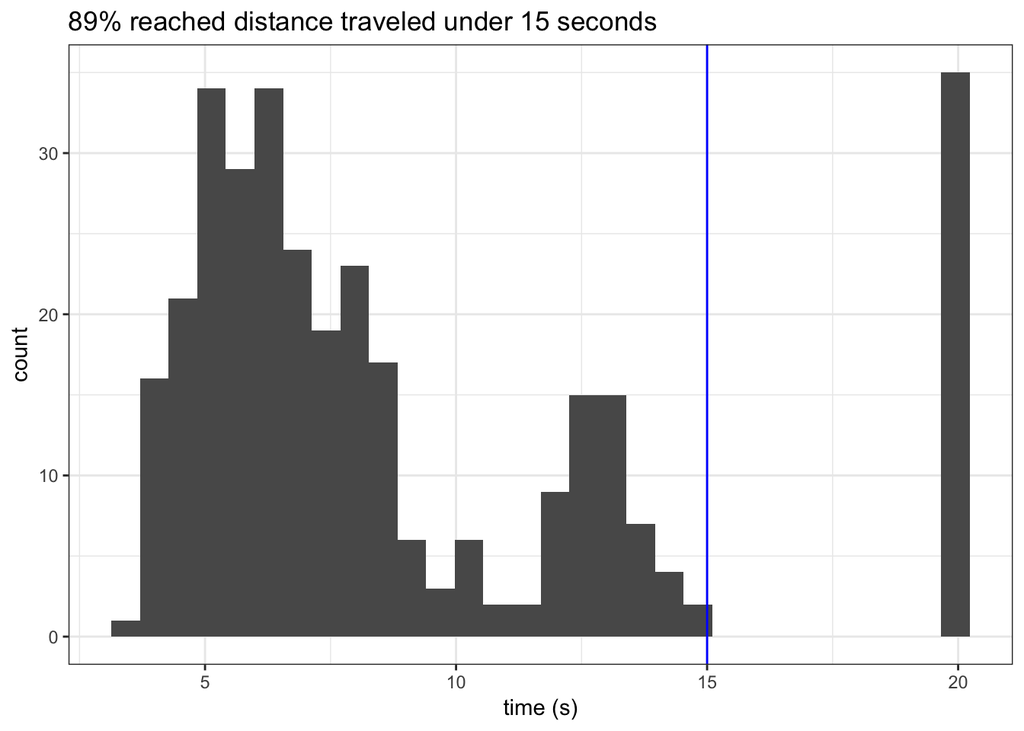

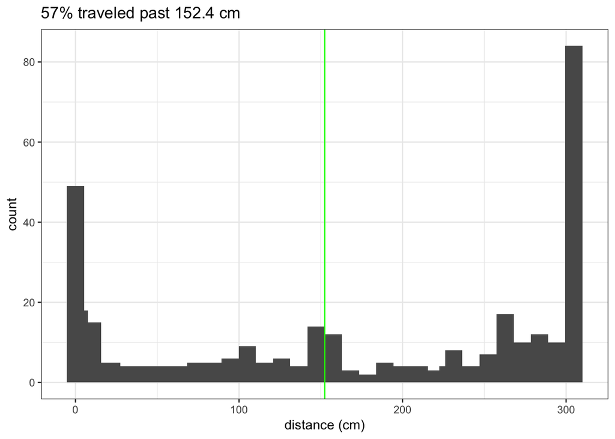

The plot below demonstrates the amount of pods that did not leave the starting point and the pods that made it to the end of the runway.

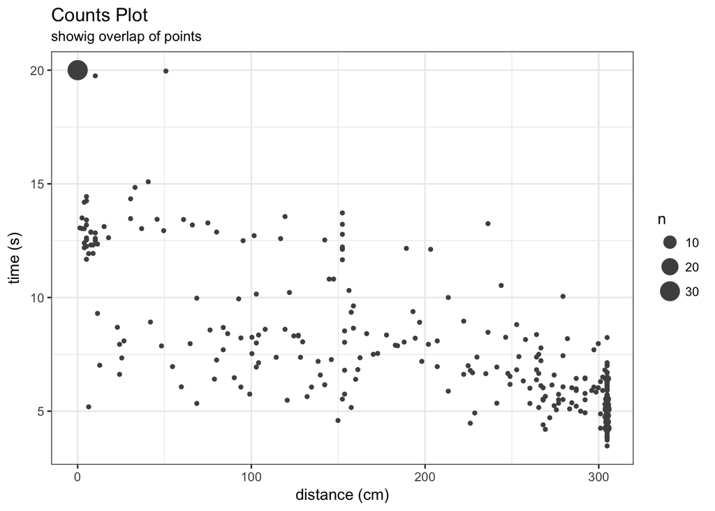

The effect of wind on pod movement was evident during trials. But knowing that over 50% of our selection from the population moved a good distance in a short time is confirmation of wind as a dispersal component.

```r
### modeling
mod1 = aov(distance_cm ~ speed*time_s*slope*substrate, data = tidy_dat)
summary(mod1)
```

```
##                               Df  Sum Sq Mean Sq F value   Pr(>F)
## speed                          2 2027257 1013628 487.512  < 2e-16 ***
## time_s                         1 1262384 1262384 607.152  < 2e-16 ***
## slope                          4   25948    6487   3.120 0.015620 *
## substrate                      2  221619  110810  53.295  < 2e-16 ***
## speed:time_s                   2  165555   82778  39.813 7.04e-16 ***
## speed:slope                    8   23892    2986   1.436 0.181217
## time_s:slope                   4   17707    4427   2.129 0.077489 .
## speed:substrate                4   58724   14681   7.061 2.02e-05 ***
## time_s:substrate               2   30766   15383   7.399 0.000744 ***
## slope:substrate                2   23743   11871   5.710 0.003727 **
## speed:time_s:slope             8   37326    4666   2.244 0.024675 *
## speed:time_s:substrate         4   14266    3566   1.715 0.146818
## speed:slope:substrate          4   44455   11114   5.345 0.000371 ***
## time_s:slope:substrate         2    4903    2451   1.179 0.309178
## speed:time_s:slope:substrate   4    4619    1155   0.555 0.695275
## Residuals                    270  561381    2079
## ---
## Signif. codes:  0 '***' 0.001 '**' 0.01 '*' 0.05 '.' 0.1 ' ' 1
```

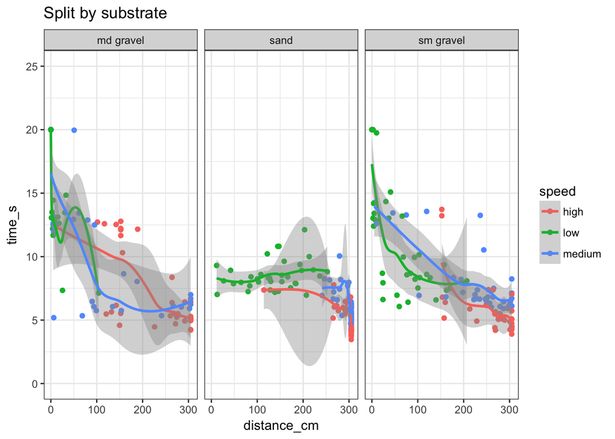

### Conclusion/Acknowledgements

This investigation fills knowledge gaps in dispersal processes and provides valuable information for conservation efforts of this federally listed endangered species.